# Prediction Assignment For Determining Fitness Exercise Correctness

### Abstract

In this assignment, I build a predictive model to determine whether a particular from of exercise is peformed correctly, using accelerometer data. The data set used is originally from http://groupware.les.inf.puc-rio.br/har (see the section on the Weight Lifting Exercise Dataset).

### Set Libraries

Preparing the library for the analysis.

```r
library(caret)
library(tree)
library(rattle)
library(rpart.plot)
library(randomForest)
set.seed(12345)
```

### Loading Data

The dataset from can be downloaded as follows

```r
if(!file.exists("pml-training.csv")) {
    download.file("http://d396qusza40orc.cloudfront.net/predmachlearn/pml-training.csv", destfile="pml-training.csv")
}
if(!file.exists("pml-testing.csv")) {
    download.file("http://d396qusza40orc.cloudfront.net/predmachlearn/pml-testing.csv", destfile="pml-testing.csv")
}

tr.org <- read.csv("pml-training.csv", na.strings=c("", "NA", "NULL"))
te.org <- read.csv("pml-testing.csv", na.strings=c("", "NA", "NULL"))
dim(tr.org)
```

```
## [1] 19622   160
```

```r
dim(te.org)
```

```
## [1]  20 160
```

### Preprocessing the data

There are several approaches for reducing the number of predictors.

- Remove variables that we believe have too many NA values.

```r
tr.dena <- tr.org[, colSums(is.na(tr.org)) == 0]
dim(tr.dena)
```

```
## [1] 19622    60
```

- Remove unrelevant variables. Threre are some unrelevant that can be removed as they are unlikely to be related to dependent variable.

```r
cols.remove <- c('X', 'user_name', 'raw_timestamp_part_1', 'raw_timestamp_part_2', 'cvtd_timestamp', 'new_window', 'num_window')
tr.dere <- tr.dena[, -which(names(tr.dena) %in% cols.remove)]
dim(tr.dere)
```

```
## [1] 19622    53
```

- Check the variables that have extremely low variance.

```r
zero.var <- nearZeroVar(tr.dere[sapply(tr.dere, is.numeric)], saveMetrics=TRUE)
zero.var
```

```
##                      freqRatio percentUnique zeroVar   nzv
## roll_belt             1.101904     6.7781062   FALSE FALSE
## pitch_belt            1.036082     9.3772296   FALSE FALSE
## yaw_belt              1.058480     9.9734991   FALSE FALSE
## total_accel_belt      1.063160     0.1477933   FALSE FALSE
## gyros_belt_x          1.058651     0.7134849   FALSE FALSE
## gyros_belt_y          1.144000     0.3516461   FALSE FALSE
## gyros_belt_z          1.066214     0.8612782   FALSE FALSE
## accel_belt_x          1.055412     0.8357966   FALSE FALSE
## accel_belt_y          1.113725     0.7287738   FALSE FALSE
## accel_belt_z          1.078767     1.5237998   FALSE FALSE
## magnet_belt_x         1.090141     1.6664968   FALSE FALSE
## magnet_belt_y         1.099688     1.5187035   FALSE FALSE
## magnet_belt_z         1.006369     2.3290184   FALSE FALSE
## roll_arm             52.338462    13.5256345   FALSE FALSE
## pitch_arm            87.256410    15.7323412   FALSE FALSE
## yaw_arm              33.029126    14.6570176   FALSE FALSE
## total_accel_arm       1.024526     0.3363572   FALSE FALSE
## gyros_arm_x           1.015504     3.2769341   FALSE FALSE
## gyros_arm_y           1.454369     1.9162165   FALSE FALSE
## gyros_arm_z           1.110687     1.2638875   FALSE FALSE
## accel_arm_x           1.017341     3.9598410   FALSE FALSE
## accel_arm_y           1.140187     2.7367241   FALSE FALSE
## accel_arm_z           1.128000     4.0362858   FALSE FALSE
## magnet_arm_x          1.000000     6.8239731   FALSE FALSE
## magnet_arm_y          1.056818     4.4439914   FALSE FALSE
## magnet_arm_z          1.036364     6.4468454   FALSE FALSE
## roll_dumbbell         1.022388    84.2065029   FALSE FALSE
## pitch_dumbbell        2.277372    81.7449801   FALSE FALSE
## yaw_dumbbell          1.132231    83.4828254   FALSE FALSE
## total_accel_dumbbell  1.072634     0.2191418   FALSE FALSE
## gyros_dumbbell_x      1.003268     1.2282132   FALSE FALSE
## gyros_dumbbell_y      1.264957     1.4167771   FALSE FALSE
## gyros_dumbbell_z      1.060100     1.0498420   FALSE FALSE
## accel_dumbbell_x      1.018018     2.1659362   FALSE FALSE
## accel_dumbbell_y      1.053061     2.3748853   FALSE FALSE
## accel_dumbbell_z      1.133333     2.0894914   FALSE FALSE
## magnet_dumbbell_x     1.098266     5.7486495   FALSE FALSE
## magnet_dumbbell_y     1.197740     4.3012945   FALSE FALSE
## magnet_dumbbell_z     1.020833     3.4451126   FALSE FALSE
## roll_forearm         11.589286    11.0895933   FALSE FALSE
## pitch_forearm        65.983051    14.8557741   FALSE FALSE
## yaw_forearm          15.322835    10.1467740   FALSE FALSE
## total_accel_forearm   1.128928     0.3567424   FALSE FALSE
## gyros_forearm_x       1.059273     1.5187035   FALSE FALSE
## gyros_forearm_y       1.036554     3.7763735   FALSE FALSE
## gyros_forearm_z       1.122917     1.5645704   FALSE FALSE
## accel_forearm_x       1.126437     4.0464784   FALSE FALSE
## accel_forearm_y       1.059406     5.1116094   FALSE FALSE
## accel_forearm_z       1.006250     2.9558659   FALSE FALSE
## magnet_forearm_x      1.012346     7.7667924   FALSE FALSE
## magnet_forearm_y      1.246914     9.5403119   FALSE FALSE
## magnet_forearm_z      1.000000     8.5771073   FALSE FALSE
```

```r
tr.nonzerovar <- tr.dere[, zero.var[, 'nzv']==0]
dim(tr.nonzerovar)
```

```
## [1] 19622    53
```

- Remove highly correleated variables 90%

```r
corr.mat <- cor(na.omit(tr.nonzerovar[sapply(tr.nonzerovar, is.numeric)]))
dim(corr.mat)
```

```
## [1] 52 52
```

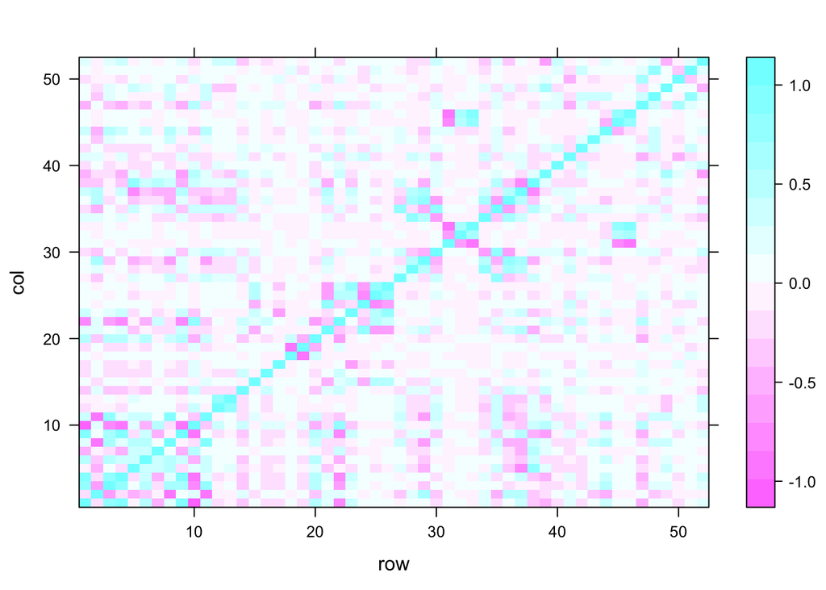

```r
corr.df <- expand.grid(row=1:dim(corr.mat)[1], col=1:dim(corr.mat)[2])
corr.df$correlation <- as.vector(corr.mat)
levelplot(correlation ~ row + col, corr.df)
```

```r
rm.corr <- findCorrelation(corr.mat, cutoff=.90, verbose=FALSE)
tr.decor <- tr.nonzerovar[, -rm.corr]
dim(tr.decor)
```

```
## [1] 19622    46
```

We get the data that has 19,622 samples 46 variables.

- Split data to trainig and testing for cross validation.

```r
in.train <- createDataPartition(y=tr.decor$class, p=0.7, list=FALSE)
tr.set <- tr.decor[in.train,]
te.set <- tr.decor[-in.train,]
c("tr.set:", dim(tr.set), "te.set:", dim(te.set))
```

```
## [1] "tr.set:" "13737"   "46"      "te.set:" "5885"    "46"
```

Finally, we got 13,737 samples and 46 variables for training set, also 5,885 samples and 46 variables for testing set.

### Analysis

Now we fit a tree to these data, and summarize and plot it. First, we use the *tree* packages.

```r
set.seed(12345)
tree.tr <- tree(classe ~ ., data=tr.set)
summary(tree.tr)
```

```
##
## Classification tree:
## tree(formula = classe ~ ., data = tr.set)
## Variables actually used in tree construction:
##  [1] "pitch_forearm"     "magnet_belt_y"     "accel_forearm_z"
##  [4] "magnet_dumbbell_y" "roll_forearm"      "magnet_dumbbell_z"
##  [7] "pitch_belt"        "yaw_belt"          "accel_dumbbell_y"
## [10] "accel_forearm_x"   "accel_dumbbell_z"  "yaw_forearm"
## [13] "magnet_forearm_z"
## Number of terminal nodes:  24
## Residual mean deviance:  1.518 = 20820 / 13710
## Misclassification error rate: 0.2965 = 4073 / 13737
```

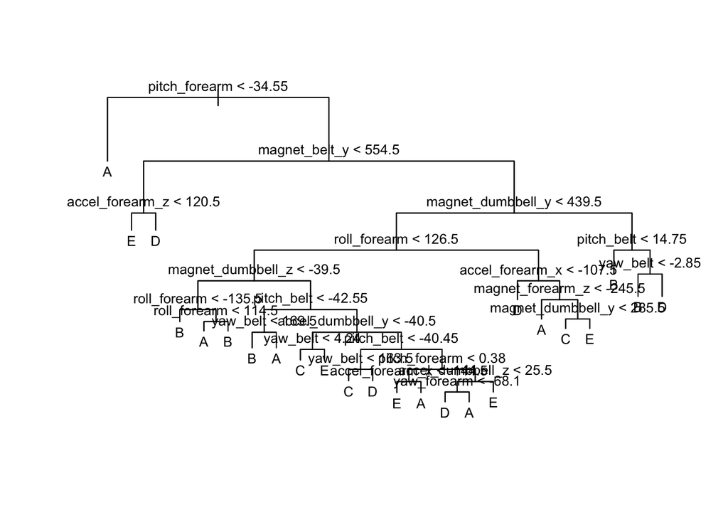

```r
plot(tree.tr)
text(tree.tr, pretty=0, cex=.8)
```

- **Use Rpart from caret**

```r
model.fit <- train(classe ~ ., method="rpart", data=tr.set)
print(model.fit)
```

```
## CART
##
## 13737 samples
##    45 predictor
##     5 classes: 'A', 'B', 'C', 'D', 'E'
##
## No pre-processing
## Resampling: Bootstrapped (25 reps)
## Summary of sample sizes: 13737, 13737, 13737, 13737, 13737, 13737, ...
## Resampling results across tuning parameters:
##
##   cp          Accuracy   Kappa      Accuracy SD  Kappa SD
##   0.02980368  0.5114567  0.3683481  0.02229275   0.03532278
##   0.03448276  0.4907128  0.3408874  0.02169962   0.03616729
##   0.06535449  0.3651812  0.1337352  0.09283392   0.15407315
##
## Accuracy was used to select the optimal model using  the largest value.
## The final value used for the model was cp = 0.02980368.
```

- **Prettier plots**

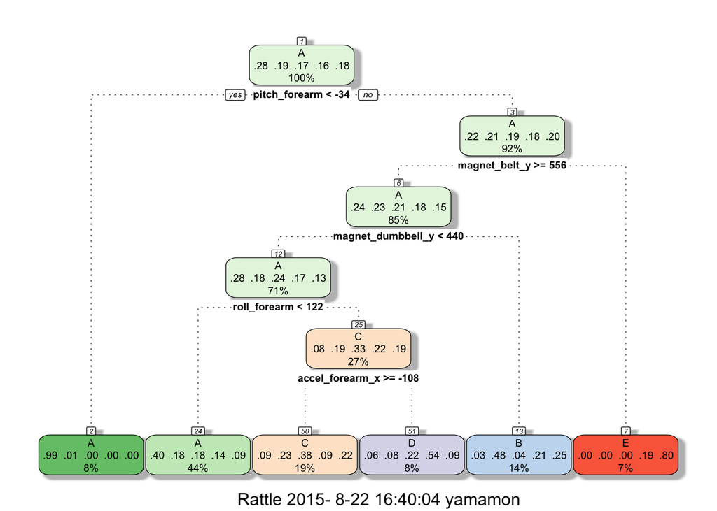

```r
fancyRpartPlot(model.fit$finalModel)
```

- **Cross Validation**

We are going to check the performance of the tree on the testing set.

```r
t.tree.pred <- predict(tree.tr, te.set, type="class")
t.confusion.mat <- with(te.set, table(t.tree.pred, classe))
sum(diag(t.confusion.mat)) / sum(as.vector(t.confusion.mat))
```

```
## [1] 0.6934579
```

We got the accuracy *0.693* from *tree* package model.

```r
c.tree.pred <- predict(model.fit, te.set)
c.confusion.mat <- with(te.set, table(c.tree.pred, classe))
sum(diag(c.confusion.mat)) / sum(as.vector(c.confusion.mat))
```

```
## [1] 0.497876
```

On the other hand, we got the accuracy *0.50* from *caret* package model.

- **Trying Pruning tree**

This tree was grown to full depth, and might be too variable. We now use cross validation to prune it.

```r
cv.tr = cv.tree(tree.tr, FUN=prune.misclass)
cv.tr
```

```
## $size
##  [1] 24 22 21 19 17 16 14 12  6  5  1
##
## $dev
##  [1] 4350 4502 4506 4755 4818 5358 5769 6529 6840 7285 9831
##
## $k
##  [1]  -Inf  90.0  91.0 119.0 126.0 161.0 174.5 189.0 203.0 337.0 638.5
##
## $method
## [1] "misclass"
##
## attr(,"class")
## [1] "prune"         "tree.sequence"
```

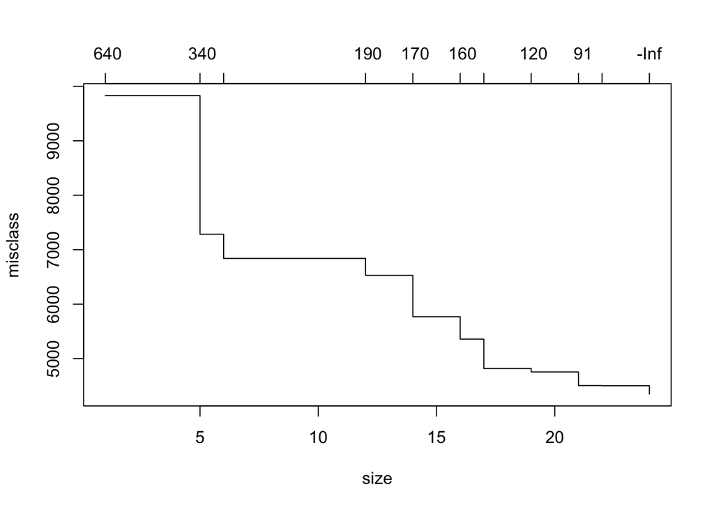

```r
plot(cv.tr)
```

### Random Forests

These methods use threes as building blocks to build more complex models.

- **Random Forests**

Random forests build lots of bushy trees, and then average them to reduce the variance.

Fit a random forest and see how well it peforms.

```r
set.seed(12345)
rf.tr <- randomForest(classe ~ ., data=tr.set, ntree=100, importance=TRUE)
rf.tr
```

```
##
## Call:
##  randomForest(formula = classe ~ ., data = tr.set, ntree = 100,      importance = TRUE)
##                Type of random forest: classification
##                      Number of trees: 100
## No. of variables tried at each split: 6
##
##         OOB estimate of  error rate: 0.6%
## Confusion matrix:
##      A    B    C    D    E  class.error
## A 3903    2    0    0    1 0.0007680492
## B   14 2632   11    0    1 0.0097817908
## C    0   18 2376    2    0 0.0083472454
## D    1    0   26 2223    2 0.0128774423
## E    0    1    3    1 2520 0.0019801980
```

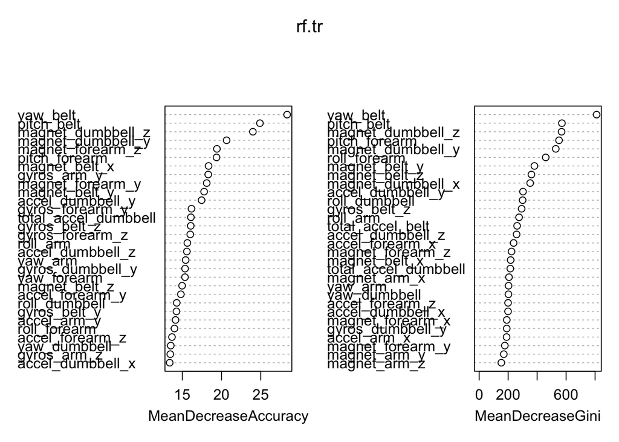

```r
varImpPlot(rf.tr)
```

### Out-of Sample Accuracy

Lets evaluate the fandom forest tree model on the test set.

```r
rf.tree.pred <- predict(rf.tr, te.set, type="class")
rf.confusion.mat <- with(te.set, table(rf.tree.pred, classe))
sum(diag(rf.confusion.mat)) / sum(as.vector(rf.confusion.mat))
```

```
## [1] 0.9938828
```

We got very hight accuracy *0.99* from *randomForest* package model.

### Conclusion

Now we can predict the testing data.

```r
ans <- predict(rf.tr, te.org)
ans
```

```
##  1  2  3  4  5  6  7  8  9 10 11 12 13 14 15 16 17 18 19 20
##  B  A  B  A  A  E  D  B  A  A  B  C  B  A  E  E  A  B  B  B
## Levels: A B C D E
```